# Capstone_2

## Capstone Project 2 : Black Friday Purchase Analysis

### Team

- Shikha
- Naveen
- Lingadhar

### Description

A retail company “ABC Private Limited” wants to understand the customer purchase behaviour (specifically, purchase amount) during theh black friday season against various products of different categories. They have shared purchase summary of various customers for selected high-volume products from last month.

The data set also contains customer demographics (age, gender, marital status, city_type, stay_in_current_city), product details (product_id and product category) and Total purchase_amount from last month.

### Objectives

- Statistical Analysis
- Data Manipulation

```python
#Load the required libraries
import os
import pandas as pd
import numpy as np
import re
import seaborn as sns
from matplotlib import pyplot

os.chdir('C:\\Users\\lduggirala\\Desktop\\Bootcamp\\Capstone Project2_ Retail\\Capstone Project2_ Retail\\Retail_datasets_P2')

#Commands to display max number of rows and columns
pd.set_option('display.max_rows',65000)
pd.set_option('display.max_columns', 500)
pd.set_option('display.width', 1000)
```

```python
#Import the data
User_Info=pd.read_csv('user_demographics.csv')
User_Purchase_Info=pd.read_csv('User_product_purchase_details_p2.csv')
```

```python
# Display the NULL/Missing values
User_Purchase_Info.isnull().sum()
```

```
User_ID                            0
Product_ID                         0
City_Category                      0
Stay_In_Current_City_Years         0
Marital_Status                     0
Product_Category_1                 0
Product_Category_2            173638
Product_Category_3            383247
Purchase                           0
dtype: int64
```

#### Inference from the above output - Null values in Product_Categories 2 and 3 signify the unavailability of a given product in those categories. Hence they don't need imputation

```python
#Merge the two datasets
User_Data=pd.merge(User_Purchase_Info,User_Info,left_on='User_ID',right_on='User_ID',how='left')
```

```python
#Re-order the columns
User_Data=User_Data[['User_ID',
 'Product_ID',
 'City_Category',
 'Stay_In_Current_City_Years',
 'Marital_Status',
 'Age',
 'Gender',
 'Occupation',
 'Product_Category_1',
 'Product_Category_2',
 'Product_Category_3',
 'Purchase',
]]
```

```python
User_Data['Occupation'] = User_Data['Occupation'].apply(str)
```

Converted Occupation to object for statistical analysis

```python
User_Data.head(2)
```

[output not shown]

```python
pd.concat([User_Data[User_Data.Product_ID.isin(['P00000342'])][['Product_ID','Product_Category_1','Product_Category_2','Product_Category_3']].head(2),User_Data[User_Data.Product_ID.isin(['P00000142'])][['Product_ID','Product_Category_1','Product_Category_2','Product_Category_3']].head(2)],axis=0)
```

|  | Product_ID | Product_Category_1 | Product_Category_2 | Product_Category_3 |
| --- | --- | --- | --- | --- |
| 2950 | P00000342 | 5 | 14.0 | NaN |
| 16796 | P00000342 | 5 | 14.0 | NaN |
| 293 | P00000142 | 3 | 4.0 | 5.0 |
| 1066 | P00000142 | 3 | 4.0 | 5.0 |

## Task 1.3 : Statistical Analysis

### Parametric tests (Based on distributions)

##### Univariate Analysis

```python
print("Mean Purchase amount of Male Customers is: ",User_Data[User_Data.Gender=='M']['Purchase'].mean())
print("Mean Purchase amount of Female Customers is: ",User_Data[User_Data.Gender=='F']['Purchase'].mean())
```

```
Mean Purchase amount of Male Customers is:  9437.526040472265
Mean Purchase amount of Female Customers is:  8734.565765155476
```

#### Male customer spending is higher than female customer spending as per the above observations. But is it significant enough?

Building a hypothesis and comparing the P-value(computed through 2 sample T test) with the standard measure of significance(0.05) could answer this

##### H0 : Null Hypothesis : There is no significant difference between male and female purchase behaviour

##### H1 : Alternate Hypothesis : There is significant difference between male and female purchase behaviour

```python
# Two sample T-Test

from scipy.stats import ttest_ind
tstat, pval = ttest_ind(User_Data[User_Data.Gender=='F']['Purchase'], User_Data[User_Data.Gender=='M']['Purchase'])
print("p-value",pval)

if pval <0.05:
    print("we reject null hypothesis / we accept alternate hypothesis")
else:
    print("we accept null hypothesis")
```

```
p-value 0.0
we reject null hypothesis / we accept alternate hypothesis
```

#### Conclusion : There is significant difference between male and female purchases. Hence Gender has a significant impact on purchase

##### Multi-variate Analysis

```python
User_Data.groupby(['Age','Gender','City_Category'],as_index=False)['Purchase'].mean()
```

|  | Age | Gender | City_Category | Purchase |
| --- | --- | --- | --- | --- |
| 0 | 0-17 | F | A | 7826.252246 |
| 1 | 0-17 | F | B | 8846.238339 |
| 2 | 0-17 | F | C | 8313.388701 |
| 3 | 0-17 | M | A | 9655.655424 |
| 4 | 0-17 | M | B | 8946.030233 |
| 5 | 0-17 | M | C | 9365.363025 |
| 6 | 18-25 | F | A | 8151.940820 |
| 7 | 18-25 | F | B | 8024.474499 |
| 8 | 18-25 | F | C | 9080.970478 |
| 9 | 18-25 | M | A | 9034.719787 |
| 10 | 18-25 | M | B | 9404.652039 |
| 11 | 18-25 | M | C | 9881.569872 |
| 12 | 26-35 | F | A | 8701.506775 |
| 13 | 26-35 | F | B | 8568.878015 |
| 14 | 26-35 | F | C | 9056.760825 |
| 15 | 26-35 | M | A | 9030.545010 |
| 16 | 26-35 | M | B | 9326.538127 |
| 17 | 26-35 | M | C | 10052.349437 |
| 18 | 36-45 | F | A | 8716.853624 |
| 19 | 36-45 | F | B | 8755.274887 |
| 20 | 36-45 | F | C | 9406.433724 |
| 21 | 36-45 | M | A | 9089.917743 |
| 22 | 36-45 | M | B | 9215.269979 |
| 23 | 36-45 | M | C | 10040.668889 |
| 24 | 46-50 | F | A | 8735.585600 |
| 25 | 46-50 | F | B | 8619.864616 |
| 26 | 46-50 | F | C | 9122.771686 |
| 27 | 46-50 | M | A | 8272.417964 |
| 28 | 46-50 | M | B | 9535.179831 |
| 29 | 46-50 | M | C | 9720.595405 |
| 30 | 51-55 | F | A | 8710.023622 |
| 31 | 51-55 | F | B | 8876.350695 |
| 32 | 51-55 | F | C | 9377.025303 |
| 33 | 51-55 | M | A | 9837.063180 |
| 34 | 51-55 | M | B | 9486.942732 |
| 35 | 51-55 | M | C | 9925.189470 |
| 36 | 55+ | F | A | 9240.678571 |
| 37 | 55+ | F | B | 9010.011103 |
| 38 | 55+ | F | C | 8980.591746 |
| 39 | 55+ | M | A | 8400.335307 |
| 40 | 55+ | M | B | 10084.874049 |
| 41 | 55+ | M | C | 9530.313690 |

#### The average purchases made by the people segmented by their Age,City_Category and Gender seem to be more or less the same as per the above data.

##### Hence the Null hypothesis(H0) should be formulated as "Age,City_Category and Gender have no impact on the purchase together/independently

This can be answered through Two way ANOVA test

```python
import statsmodels.api as sm
from statsmodels.formula.api import ols

formula = 'Purchase ~ C(Age) + C(Gender) + C(City_Category) + C(Age):C(Gender):C(City_Category)'
model = ols(formula, User_Data).fit()
aov_table = sm.stats.anova_lm(model, typ=2)
aov_table
```

|  | sum_sq | df | F | PR(>F) |
| --- | --- | --- | --- | --- |
| C(Age) | 5.825327e+09 | 6.0 | 38.860427 | 1.657430e-47 |
| C(Gender) | 4.972546e+10 | 1.0 | 1990.294586 | 0.000000e+00 |
| C(City_Category) | 5.728159e+10 | 2.0 | 1146.366858 | 0.000000e+00 |
| C(Age):C(Gender):C(City_Category) | 2.351731e+10 | 32.0 | 29.415500 | 5.648113e-177 |
| Residual | 1.374183e+13 | 550026.0 | NaN | NaN |

#### Conclusion : The P values (PR(>F)) are way below the significance value 0.05. Hence it can be inferred that both Age,City_Category and Gender impact the purchases independently as well as together

### Non-Parametric tests (Distribution free tests)

```python
pd.crosstab(User_Data.Occupation,User_Data.Age)
```

| Age Occupation | 0-17 | 18-25 | 26-35 | 36-45 | 46-50 | 51-55 | 55+ |
| --- | --- | --- | --- | --- | --- | --- | --- |
| 0 | 2134 | 9095 | 34204 | 13393 | 4488 | 4602 | 1722 |
| 1 | 387 | 3820 | 19080 | 9501 | 7089 | 4410 | 3139 |
| 10 | 10951 | 1649 | 26 | 170 | 0 | 0 | 134 |
| 11 | 18 | 717 | 5009 | 2732 | 1584 | 1383 | 143 |
| 12 | 237 | 4585 | 15279 | 6848 | 2491 | 1417 | 322 |
| 13 | 15 | 0 | 0 | 427 | 631 | 1785 | 4870 |
| 14 | 93 | 4388 | 13446 | 5590 | 1445 | 1012 | 1335 |
| 15 | 0 | 906 | 6874 | 2585 | 854 | 514 | 432 |
| 16 | 0 | 1816 | 7070 | 7572 | 3032 | 3918 | 1963 |
| 17 | 35 | 3944 | 17064 | 10252 | 4662 | 2528 | 1558 |
| 18 | 0 | 1085 | 2243 | 1527 | 1124 | 531 | 112 |
| 19 | 807 | 2500 | 3468 | 1008 | 261 | 200 | 217 |
| 2 | 144 | 4364 | 12617 | 5183 | 2124 | 1344 | 812 |
| 20 | 0 | 5445 | 13994 | 7508 | 2699 | 3115 | 801 |
| 3 | 0 | 1860 | 8159 | 4126 | 1599 | 1094 | 812 |
| 4 | 113 | 48241 | 21829 | 1747 | 129 | 249 | 0 |
| 5 | 0 | 1450 | 6082 | 3066 | 1187 | 377 | 15 |
| 6 | 0 | 1144 | 7216 | 4822 | 2561 | 3952 | 660 |
| 7 | 139 | 2078 | 24060 | 18762 | 6664 | 5355 | 2075 |
| 8 | 29 | 14 | 378 | 98 | 549 | 317 | 161 |
| 9 | 0 | 559 | 1489 | 3096 | 528 | 398 | 221 |

#### Is there any association between Age and Occupation?

##### H0: Age and Occupation have no relationship with each other

##### H1: Age and Occupation have relationship with each other

```python
# Calculating chi-square statistic

from scipy import stats
chi_stat,pval,dof,expected_values = stats.chi2_contingency(pd.crosstab(User_Data.Occupation,User_Data.Age))

# Critical value

from scipy.stats import chi2
alpha = 0.05
critical_value = chi2.ppf(q=1-alpha, df=dof)
print('critical_value is:', critical_value)
```

[output not shown]

```python
print('critical_value is:', critical_value)
print('chi_stat value is:', chi_stat)

# Inference

if chi_stat>=critical_value:
    print("Reject H0, There is a relationship between Occupation and Age")
else:
    print("Accept H0, There is no relationship between Occupation and Age")
```

```
critical_value is: 146.56735758076744
chi_stat value is: 593445.4632990314
Reject H0, There is a relationship between Occupation and Age
```

#### Conclusion : Age and Occupation are dependent on each other

### Descriptive statistics for Numerical features

```python
User_Data['Purchase'].describe()
```

```
count    550068.000000
mean       9263.968713
std        5023.065394
min          12.000000
25%        5823.000000
50%        8047.000000
75%       12054.000000
max       23961.000000
Name: Purchase, dtype: float64
```

##### The mean seems to be on the higher which indicates that the distribution is skewed. Checking the same with the distribution plot.

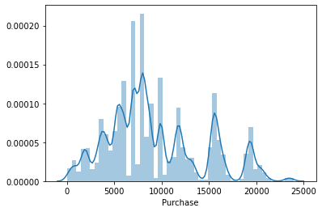

```python
sns.distplot(User_Data['Purchase'])
```

## Task 1.1 : Data Manipulation

```python
User_Data.shape
```

```
(550068, 12)
```

```python
User_Data.columns
```

```
Index(['User_ID', 'Product_ID', 'City_Category', 'Stay_In_Current_City_Years', 'Marital_Status', 'Age', 'Gender', 'Occupation', 'Product_Category_1', 'Product_Category_2', 'Product_Category_3', 'Purchase'], dtype='object')
```

#### EDA on identifying the customers to whom personalized discount vouchers can be offered

```python
user_mean_pur = User_Data.groupby('User_ID',as_index=False)['Purchase'].mean()
```

##### Binning the customers based on their Mean purchase

```python
category = pd.cut(user_mean_pur.Purchase,bins=[0,5000,8500,14000,50000],labels=['Low:0-5K','Medium:5K-8.5K','Good:8.5K-14K','Exceptional:14K-any'])
user_mean_pur.insert(2,'Avg_Purchase_Category',category)

user_mean_pur.groupby(['Avg_Purchase_Category'],as_index=False)['Purchase'].agg([np.size,min,max,np.mean])
```

| Avg_Purchase_Category | size | min | max | mean |
| --- | --- | --- | --- | --- |
| Low:0-5K | 26.0 | 2318.733333 | 4985.047619 | 4301.280860 |
| Medium:5K-8.5K | 1684.0 | 5052.873684 | 8498.650000 | 7546.690340 |
| Good:8.5K-14K | 4047.0 | 8502.555556 | 13996.516129 | 10262.942687 |
| Exceptional:14K-any | 134.0 | 14014.700000 | 18577.893617 | 15040.649563 |

**Recomendation :**

- Users labelled as 'Low' can be offered discount vouchers if their next purchase value is more than ~6K
- Users labelled as 'Medium' can be offered discount vouchers if their next purchase value is more than ~9K
- Users labelled as 'Good' can be offered discount vouchers if their next purchase value is more than ~15K
- Users labelled as 'Exceptional' can be offered discount vouchers as they stand out to be the loyal customers of the store.

```python
a=User_Data.groupby(['User_ID'],as_index=False)['Product_ID'].count().sort_values('Product_ID',ascending=False).head(10)
a=a.rename({'Product_ID':'# of Products purchased'},axis=1)
a
```

|  | User_ID | # of Products purchased |
| --- | --- | --- |
| 1634 | 1001680 | 1026 |
| 4166 | 1004277 | 979 |
| 1885 | 1001941 | 898 |
| 1142 | 1001181 | 862 |
| 863 | 1000889 | 823 |
| 3520 | 1003618 | 767 |
| 1111 | 1001150 | 752 |
| 981 | 1001015 | 740 |
| 5647 | 1005795 | 729 |
| 5683 | 1005831 | 727 |

```python
b=User_Data.groupby(['User_ID'],as_index=False)['Purchase'].sum().sort_values('Purchase',ascending=False).head(10)
b=b.rename({'Purchase':'Purchase Value'},axis=1)
b
```

|  | User_ID | Purchase Value |
| --- | --- | --- |
| 4166 | 1004277 | 10536909 |
| 1634 | 1001680 | 8699596 |
| 2831 | 1002909 | 7577756 |
| 1885 | 1001941 | 6817493 |
| 416 | 1000424 | 6573609 |
| 4335 | 1004448 | 6566245 |
| 5683 | 1005831 | 6512433 |
| 981 | 1001015 | 6511314 |
| 3297 | 1003391 | 6477160 |
| 1142 | 1001181 | 6387961 |

```python
c=User_Data.groupby(['Product_ID'],as_index=False)['Purchase'].sum().sort_values('Purchase',ascending=False).head(10)
c=c.rename({'Purchase':'Purchase Value'},axis=1)
c
```

|  | Product_ID | Purchase Value |
| --- | --- | --- |
| 249 | P00025442 | 27995166 |
| 1016 | P00110742 | 26722309 |
| 2443 | P00255842 | 25168963 |
| 582 | P00059442 | 24338343 |
| 1745 | P00184942 | 24334887 |
| 1030 | P00112142 | 24216006 |
| 1018 | P00110942 | 23639564 |
| 2263 | P00237542 | 23425576 |
| 565 | P00057642 | 23102780 |
| 104 | P00010742 | 22164153 |

#### Should the discount be offered on the product category or the total amount?

```python
set(User_Data.groupby(['User_ID','Product_ID'],as_index=False)['Purchase'].nunique().tolist())
```

```
{1}
```

```python
User_Data.columns
```

```
Index(['User_ID', 'Product_ID', 'City_Category', 'Stay_In_Current_City_Years', 'Marital_Status', 'Age', 'Gender', 'Occupation', 'Product_Category_1', 'Product_Category_2', 'Product_Category_3', 'Purchase'], dtype='object')
```

### Hence Discount can be offered on the Total purchase value only

#### Summary table derivation in order to showcase the aggregates in one dataframe in order to Identify the Loyal customer group to offer personalized discount vouchers

```python
summary=User_Data.groupby(['Age','Gender'],as_index=False).agg({'Purchase':['count','sum','mean']})
summary.columns=summary.columns.to_flat_index()
summary.columns = [re.sub('\(|\)|,|\'|\"','',str(i)).strip() for i in summary.columns.tolist()]
```

```python
summary['% Contribution to Total sales'] = summary['Purchase sum']/np.sum(User_Data['Purchase'])
```

```python
summary.sort_values('Purchase sum',ascending=False)
```

|  | Age | Gender | Purchase count | Purchase sum | Purchase mean | % Contribution to Total sales |
| --- | --- | --- | --- | --- | --- | --- |
| 5 | 26-35 | M | 168835 | 1588794345 | 9410.337578 | 0.311784 |
| 7 | 36-45 | M | 82843 | 783130921 | 9453.193643 | 0.153681 |
| 3 | 18-25 | M | 75032 | 708372833 | 9440.942971 | 0.139011 |
| 4 | 26-35 | F | 50752 | 442976233 | 8728.251754 | 0.086929 |
| 9 | 46-50 | M | 32502 | 304136539 | 9357.471509 | 0.059684 |
| 11 | 51-55 | M | 28607 | 277633647 | 9705.094802 | 0.054483 |
| 6 | 36-45 | F | 27170 | 243438963 | 8959.844056 | 0.047772 |
| 2 | 18-25 | F | 24628 | 205475842 | 8343.180201 | 0.040322 |
| 13 | 55+ | M | 16421 | 154984610 | 9438.195603 | 0.030414 |
| 8 | 46-50 | F | 13199 | 116706864 | 8842.098947 | 0.022903 |
| 1 | 0-17 | M | 10019 | 92527205 | 9235.173670 | 0.018157 |
| 10 | 51-55 | F | 9894 | 89465997 | 9042.449666 | 0.017557 |
| 12 | 55+ | F | 5083 | 45782765 | 9007.036199 | 0.008984 |
| 0 | 0-17 | F | 5083 | 42385978 | 8338.771985 | 0.008318 |

#### Purchase sum and Purchase count seem to be having a monotonic relationship. The below code checks if it's true

```python
summary[['Purchase sum','Purchase count']].corr()
```

|  | Purchase sum | Purchase count |
| --- | --- | --- |
| Purchase sum | 1.000000 | 0.999623 |
| Purchase count | 0.999623 | 1.000000 |

### Purchase value and Purchase volume are highly correlated. Hence one of them can be dropped.

```python
summary.drop('Purchase count',axis=1,inplace=True)
```

```python
summary.sort_values('Purchase sum',ascending=False)
```

[output not shown]

#### Age and Gender are the two visibly good features to narrow down the selection of the customer category to which discount vouchers can be offered on their total purchase.

#### Yet including the other features such as Occupation, City category etc along with these two to further narrow down the selection